# Homwework 8

Shubham Bhargava 2024-04-16

```r
library(readxl)
News_Website_Dataset <- read_excel("News Website Dataset.xlsx")
#View(News_Website_Dataset)

# correlation  and coefficient B/W Total_revenue and Total Sessions
correlation_coefficient2 <- cor(News_Website_Dataset$Total_revenue, News_Website_Dataset$Total_Sessions)
print(correlation_coefficient2)
```

```
## [1] 1
```

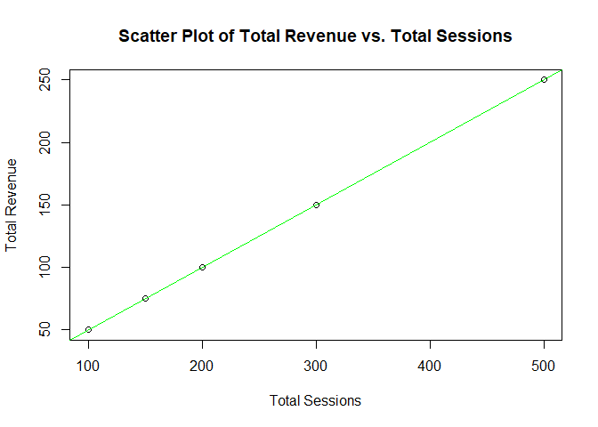

```r
plot(News_Website_Dataset$Total_Sessions, News_Website_Dataset$Total_revenue,
     xlab = "Total Sessions", ylab = "Total Revenue",
     main = "Scatter Plot of Total Revenue vs. Total Sessions")

abline(lm(News_Website_Dataset$Total_revenue ~ News_Website_Dataset$Total_Sessions), col = "green")
```

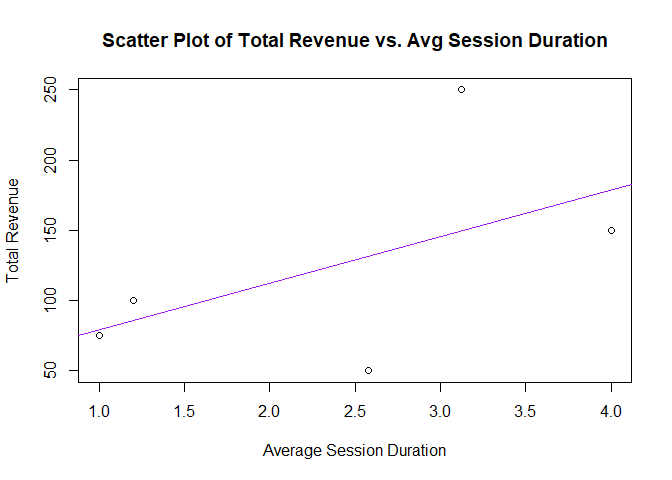

```r
correlation_coefficient <- cor(News_Website_Dataset$Total_revenue, News_Website_Dataset$Avg_Session_Duration)

plot(News_Website_Dataset$Avg_Session_Duration, News_Website_Dataset$Total_revenue,
     xlab = "Average Session Duration", ylab = "Total Revenue",
     main = "Scatter Plot of Total Revenue vs. Avg Session Duration")

abline(lm(News_Website_Dataset$Total_revenue ~ News_Website_Dataset$Avg_Session_Duration), col = "purple")
```

```r
print(paste("Correlation Coefficient between Total Revenue and Avg Session Duration:", correlation_coefficient))
```

```
## [1] "Correlation Coefficient between Total Revenue and Avg Session Duration: 0.536707214155583"
```

### Assignment 8

#### Logistic Regression Analysis

To perform logistic regression analysis, we will use the glm() function.

- Load all necessary packages
- Load Data. we Used read_excel() function to read data from excel
- Now we will use glm() function to fit a logistic regression model to the data.
- Now use summary() function for logistic regression model to view coefficients, standard errors, z-values, and p-values.
- For Residual Analysis use plot() function to get Plot diagnostic plots, including residuals vs. fitted values, QQ plot of residuals, and scale-location plot, to check for homoscedasticity and normality of residuals.

#### Model Development

```r
library(readxl)
library(dplyr)
library(ROCR)
library(pROC)
mydata <- read_excel("News Website Dataset_2.xlsx")
```

```r
threshold <- 200

mydata$Revenue_Binary <- ifelse(mydata$Total_revenue > threshold, 1, 0)

logit_model <- glm(Revenue_Binary ~  Total_Sessions
+ Conversion_Rate + Avg_Session_Duration,
                    data = mydata,
                    family = binomial)
```

In order to produce a binary result variable based on a threshold, the algorithm first reads and preprocesses a dataset.

It fits a logistic regression model using three predictor variables:

Total_Sessions, Conversion_Rate, and Avg_Session_Duration.

Defining the model formula, fitting the model to the data, and producing a summary of the model’s coefficients and statistical significance are all steps in this model development process.

#### Model Acceptance

```r
summary(logit_model)
```

```
##
## Call:
## glm(formula = Revenue_Binary ~ Total_Sessions + Conversion_Rate +
##     Avg_Session_Duration, family = binomial, data = mydata)
##
## Coefficients:
##                        Estimate Std. Error z value Pr(>|z|)
## (Intercept)          -0.8493387  0.7351481  -1.155    0.248
## Total_Sessions        0.0002231  0.0014133   0.158    0.875
## Conversion_Rate       1.1609186  0.7192518   1.614    0.107
## Avg_Session_Duration -0.1110208  0.1379476  -0.805    0.421
##
## (Dispersion parameter for binomial family taken to be 1)
##
##     Null deviance: 211.70  on 159  degrees of freedom
## Residual deviance: 208.39  on 156  degrees of freedom
## AIC: 216.39
##
## Number of Fisher Scoring iterations: 4
```

```r
anova(logit_model)
```

```
## Analysis of Deviance Table
##
## Model: binomial, link: logit
##
## Response: Revenue_Binary
##
## Terms added sequentially (first to last)
##
##
##                      Df Deviance Resid. Df Resid. Dev
## NULL                                   159     211.70
## Total_Sessions        1  0.01422       158     211.69
## Conversion_Rate       1  2.64650       157     209.04
## Avg_Session_Duration  1  0.64962       156     208.39
```

The coefficients show how each predictor variable is expected to affect the outcome variable’s log-odds of falling into the positive class (1).

For instance, the coefficient for Total_Sessions is roughly 0.0002231, meaning that the log-odds of the outcome variable falling into the positive class rises by 0.0002231 units for every unit increase in Total_Sessions.

Conversion_Rate and Avg_Session_Duration have coefficients of 1.1609186 and -0.1110208, respectively..

#### Residual Analysis

```r
# Residual Analysis
residuals(logit_model)
```

[output not shown]

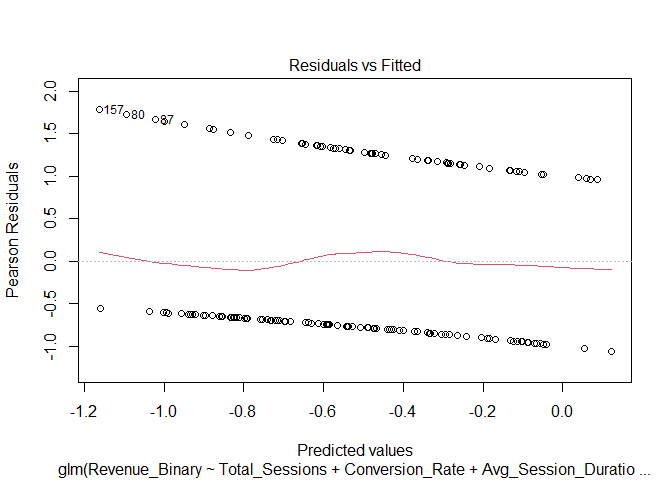

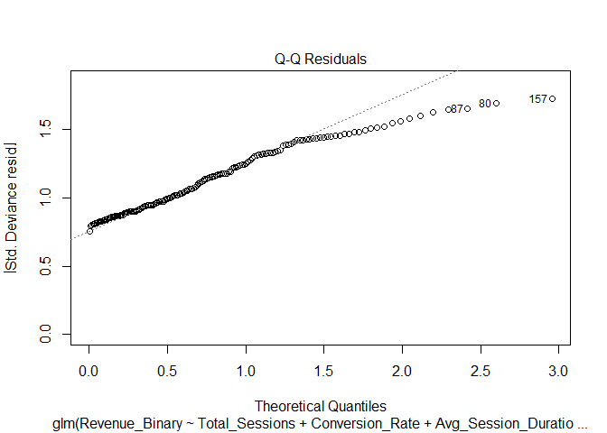

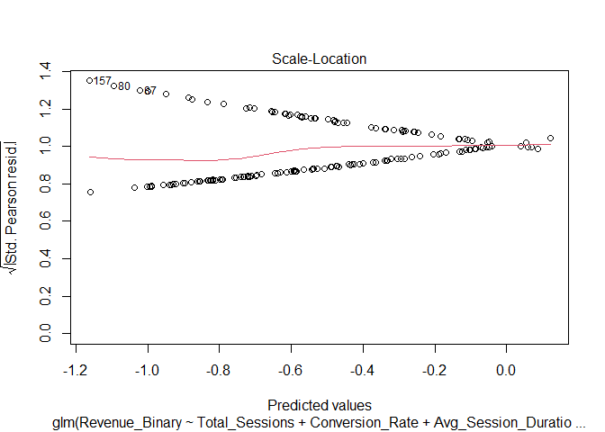

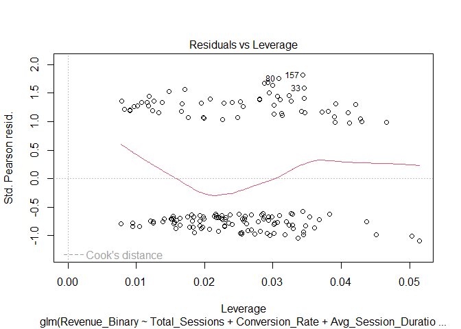

```r
plot(logit_model)
```

The function (logit_model) computes the residuals of the fitted logistic regression model. It gives back a vector with the residuals in it.

Diagnostic graphs for the logistic regression model (logit_model) are produced using the plot() function.diagnostic charts, such as the quantile-quantile (Q-Q) plot, leverage plot, and residuals versus fitted values.

#### Prediction

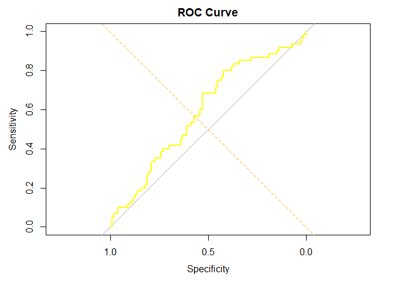

```r
predicted_prob <- predict(logit_model, type = "response")

# Create prediction object
predictions <- prediction(predicted_prob, mydata$Revenue_Binary)

roc_curve <- roc(mydata$Revenue_Binary, predicted_prob)
# Plot ROC curve
plot(roc_curve, main = "ROC Curve", col = "yellow", lwd = 2)
abline(a = 0, b = 1, lty = 2, col = "orange")
```

```r
# Calculate AUC
auc_value <- auc(roc_curve)
cat("AUC:", auc_value, "\n")
```

```
## AUC: 0.5915
```

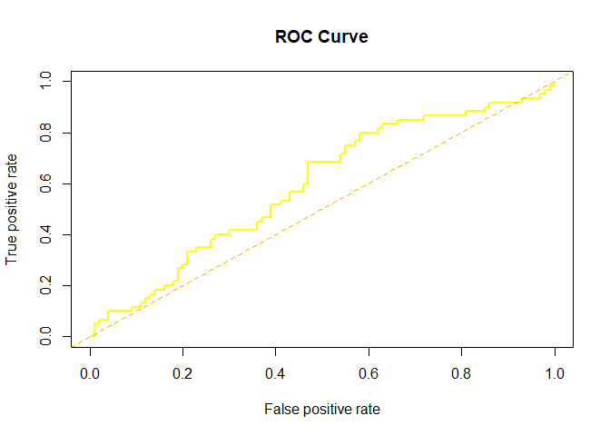

```r
# Calculate performance measures
perf <- performance(predictions, "tpr", "fpr")

# Plot ROC curve
plot(perf, main = "ROC Curve", col = "yellow", lwd = 2)
abline(a = 0, b = 1, lty = 2, col = "orange")
```

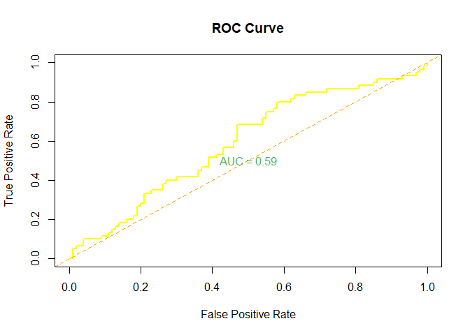

```r
# Plot ROC curve
plot(perf, main = "ROC Curve", col = "yellow", lwd = 2,
     xlab = "False Positive Rate", ylab = "True Positive Rate",
     xlim = c(0, 1), ylim = c(0, 1))
abline(a = 0, b = 1, lty = 2, col = "orange")  # Diagonal line for reference

# Add AUC value to the plot
auc_value <- performance(predictions, "auc")@y.values[[1]]
text(0.5, 0.5, paste("AUC =", round(auc_value, 2)), col = "#4daf4a", lwd=4)
```

```r
# Prediction
new_data <- mydata[1:10, ]
predictions <- predict(logit_model, newdata = new_data, type = "response")
print(predictions)
```

```
##         1         2         3         4         5         6         7         8
## 0.3027333 0.3027252 0.3048305 0.3440319 0.3614021 0.3951736 0.3323341 0.3905819
##         9        10
## 0.3125115 0.3226536
```

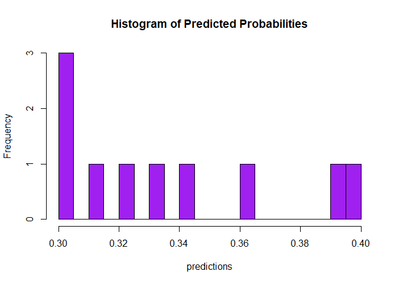

```r
hist(predictions, breaks = 20, col = "purple", main = "Histogram of Predicted Probabilities")
```

#### Model Accuracy

```r
predicted <- predict(logit_model, type = "response")
predicted_binary <- ifelse(predicted > 0.5, 1, 0)
confusion <- table(predicted_binary, mydata$Revenue_Binary)
accuracy <- sum(diag(confusion)) / sum(confusion)
print(accuracy)
```

```
## [1] 0.6375
```